# DATA EDA

CHAcha

2021 7 12

```r
library(tidyverse)
library(dynlm)
library(dynamac)
library(forecast)
library(lmtest)
library(gridExtra)
```

```r
library(dygraphs)
library(xts)
setwd("C:/Users/82106/OneDrive/바탕 화면/2021-1/SAM/DATA_SAM")
DATA<-read.csv("Data Yield Curve.csv",header = T)
sp500<-read.table("SP.txt",header = F)
oil<-read.table("oil.txt",header = F)
DATA$OIL[1:107]<-oil[,1]
DATA[511,]$OIL<-c(55.14)
sp500<-sp500[,4]
sp500<-sp500[111:1]
DATA$SP500[1:111]<-sp500
DATA$SP500[509:511]<-c(2996.11,2897.50,2982.16)
DATA$Date<-as.Date(DATA$Date)
```

## 변수설명

```
##         Date X1.yr X30YR SPREAD  SP500   GOLD  OIL CHHUSD JPYUSD
## 1 1977-03-01  5.50  7.80   2.30 100.60 148.34 8.45   2.55 280.23
## 2 1977-04-01  5.44  7.73   2.29  99.05 149.18 8.41   2.53 275.21
## 3 1977-05-01  5.84  7.80   1.95  98.76 146.54 8.49   2.52 277.43
## 4 1977-06-01  5.80  7.64   1.84  99.29 140.83 8.44   2.49 272.86
## 5 1977-07-01  5.94  7.64   1.71 100.20 143.40 8.47   2.41 264.86
## 6 1977-08-01  6.37  7.68   1.31  97.75 145.01 8.45   2.41 266.68
```

```
##       Date                X1.yr            X30YR            SPREAD
##  Min.   :1977-03-01   Min.   : 0.100   Min.   : 2.120   Min.   :-3.480
##  1st Qu.:1987-10-16   1st Qu.: 1.550   1st Qu.: 4.500   1st Qu.: 0.645
##  Median :1998-06-01   Median : 4.960   Median : 6.050   Median : 1.650
##  Mean   :1998-06-01   Mean   : 4.986   Mean   : 6.592   Mean   : 1.606
##  3rd Qu.:2009-01-16   3rd Qu.: 7.325   3rd Qu.: 8.455   3rd Qu.: 2.710
##  Max.   :2019-09-01   Max.   :16.720   Max.   :14.680   Max.   : 4.370
##      SP500              GOLD             OIL             CHHUSD
##  Min.   :  88.82   Min.   : 140.8   Min.   :  8.41   Min.   :0.780
##  1st Qu.: 271.96   1st Qu.: 341.4   1st Qu.: 19.36   1st Qu.:1.085
##  Median : 899.47   Median : 400.1   Median : 26.43   Median :1.390
##  Mean   : 930.09   Mean   : 625.7   Mean   : 39.29   Mean   :1.434
##  3rd Qu.:1332.90   3rd Qu.: 926.4   3rd Qu.: 55.74   3rd Qu.:1.650
##  Max.   :2996.11   Max.   :1780.7   Max.   :133.88   Max.   :2.800
##      JPYUSD
##  Min.   : 76.64
##  1st Qu.:106.86
##  Median :118.81
##  Mean   :139.30
##  3rd Qu.:147.40
##  Max.   :280.23
```

### 시간의 따른 변수들의 변화 과정

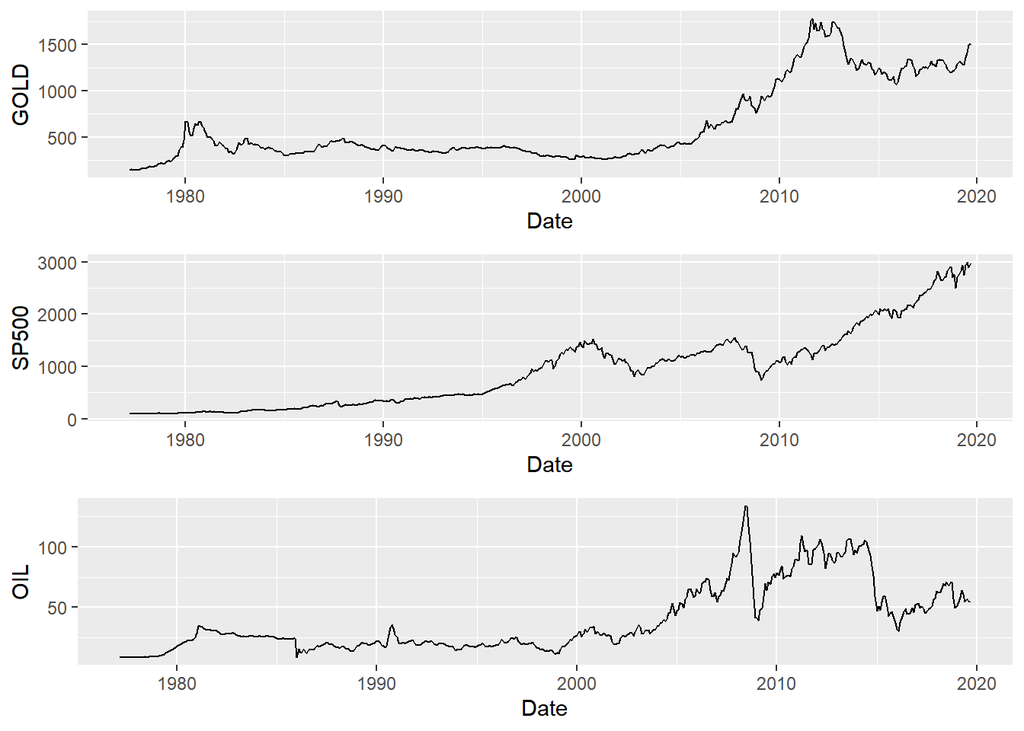

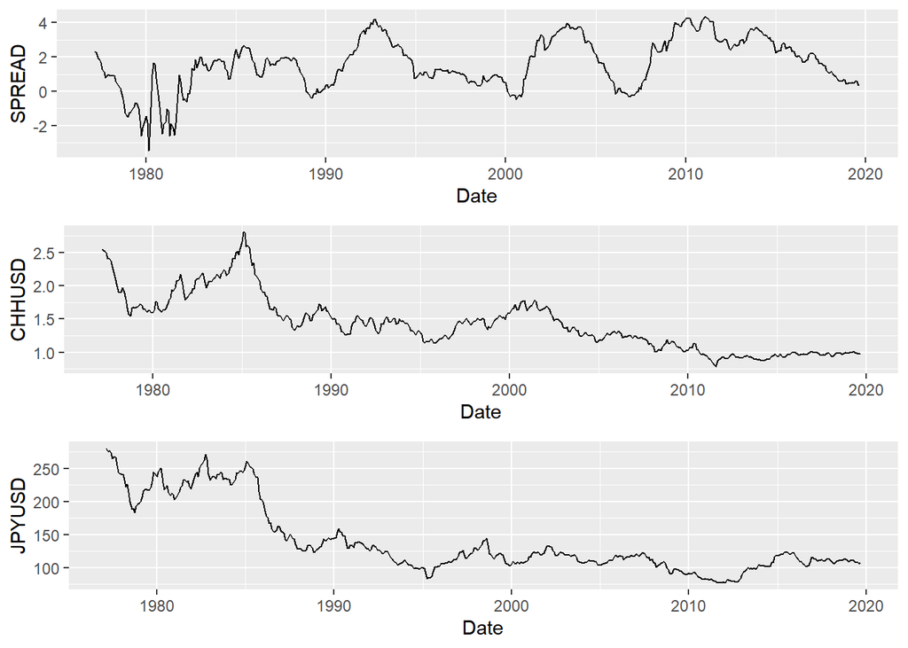

1. 금 값은 1980년 기점으로 최고가를 경신하고 이 후 가격 변동이 많이 없다가, 2005년 기점으로 가파른 상승
2. SP500 지수는 2000년/ 2008년 두 번 하방으로 간 것을 제외하면 대체로 우상향하는 패턴을 보임
3. 유가는 80년도 들어 상승 하다가 85~6년 사이 급격한 하락 이후 2007년 부근 매우 가파르게 상승
4. 스프레드는 랜덤한 경향을 띄지만 80~81년 사이 가파른 상승이 한번 일어남.
5. 환율은 두 국가모두 85년 기점으로 큰 폭으로 하락하고이 이후 비교적 안정적인 형태.

[interactive chart not shown]

1. IT 버블의 붕괴 : 1990년대 비약적인 성장을 기록 하였던, 미국의 중심에는 IT기업들이 있었음. 실제로 많은 주가 상승을 견인했지만, 실체는 건전하지 못한 많은 기업들이 존재하였고, 묻지마 투자가 많이 일어나 결국 버블이 붕괴되어 주가 지수 폭락 => 연준은 기준금리를 인하하여 대응.
2. 글로벌 금융위기(서브프라임 모기지 사태) : 서브 프라임 모기지 사태 사태의 발단은 2000년대 초반부터 시작되었다. 2000년대 초반 IT버블 붕괴, 911테러, 아프간/이라크 전쟁 등으로, 미국 경기가 악화되자 이에 미국은 경기부양책으로 초 저금리 정책을 펼쳤다. 이에 따라 주택융자 금리가 인하되었고 그러자 부동산가격이 상승하기 시작했다. 주택담보대출인 서브프라임모기지의 대출금리보다 높은 상승률을 보이는 주택가격 때문에 파산하더라도 주택가격 상승으로 보전되어 금융회사가 손해를 보지 않는 구조여서 거래량은 대폭 증가하였다. 증권화된 서브프라임 모기지론은 높은 수익률이 보장되며 신용등급이 높은 상품으로 알려져 거래량이 폭증했다.

하지만, 2004년 미국이 저금리 정책을 종료하면서 미국 부동산 버블이 꺼지기 시작했으며, 서브프라임모기지론 금리가 올라갔고 저소득층 대출자들은 원리금을 제대로 갚지 못하게 된다. 증권화되어 거래된 서브프라임 모기지론을 구매한 금융기관들은 대출금 회수불능사태에 빠져 손실이 발생했고, 그 과정에 여러 기업들이 부실화된다. 미 정부는 개입을 공식적으로 부정했고 미국의 대형 금융사, 증권회사의 파산이 이어졌다. 이것이 세계적인 신용경색을 가져왔고 실물경제에 악영향을 주었고, 이는 세계 경제시장에까지 타격을 주어 2008년 이후에 세계금융위기까지 이어지게 되었다.

## BACKGROUNND STORY

[interactive chart not shown]

### 알 수 있는점

1. 대부분 30년 만기 국채금리가 이자율이 높지만, 그렇지 않은경우 종종 발견(SPREAD값이 음수) 1980년대 초반의 경제 상황을 살펴볼 필요가 있음.
- 제2차 석유파동, 이란-이라크의 전쟁으로 인하여 국제유가 매우상승 -> 미국 국채가 가파르게 중가 -> 이후 레이건 대통령 집권 -> Fed, 폴 볼커 의장으로 임명 -> 물가를 잡기위해 기준금리 20% 육박하도록 상승 -> 이후 80년대 중~후반 금리 안정
2. 90년대 가파른 금리하락이 일어남 -> 본격적인 경기 호황기
3. 2008년 이후 급격한 금리하락이 일어남 -> 글로벌 금융위기를 맞아 금리를 인하하는 정책을 사용한 결과
4. 2017~2019년에 금리는 상승

[interactive chart not shown]

### 플라자 합의란?

- 미국의 달러강세 지속 -> 무역수지 적자가 발생(특히 대일적자가 극심) -> 미국이 선진국들에게 대미 환율 절하를 요청 -> 선진국들이 이를 받아들임 -> 너무 심한 엔고현상이 발생 -> 역플라자합의(1995.4)

-이후 2013년 부터 환율 증가. 아베노믹스의 영향으로 추정

```r
cor(DATA[,-1])
```

```
##             X1.yr      X30YR     SPREAD      SP500       GOLD        OIL
## X1.yr   1.0000000  0.9388343 -0.7276304 -0.7184898 -0.6222638 -0.6011341
## X30YR   0.9388343  1.0000000 -0.4469007 -0.8370462 -0.6388758 -0.5946304
## SPREAD -0.7276304 -0.4469007  1.0000000  0.1991319  0.3440430  0.3772517
## SP500  -0.7184898 -0.8370462  0.1991319  1.0000000  0.7075009  0.6163656
## GOLD   -0.6222638 -0.6388758  0.3440430  0.7075009  1.0000000  0.8198233
## OIL    -0.6011341 -0.5946304  0.3772517  0.6163656  0.8198233  1.0000000
## CHHUSD  0.7597702  0.8169158 -0.3465350 -0.7104849 -0.7087509 -0.6415025
## JPYUSD  0.7860788  0.8095275 -0.4294542 -0.6196254 -0.4762130 -0.4923942
##            CHHUSD     JPYUSD
## X1.yr   0.7597702  0.7860788
## X30YR   0.8169158  0.8095275
## SPREAD -0.3465350 -0.4294542
## SP500  -0.7104849 -0.6196254
## GOLD   -0.7087509 -0.4762130
## OIL    -0.6415025 -0.4923942
## CHHUSD  1.0000000  0.8661878
## JPYUSD  0.8661878  1.0000000
```